# Tipología y ciclo de vida de los datos

# Práctica 2 - Limpieza y análisis de datos

Miguel Angel Sosvilla Luis

Diciembre 2020

# 1 Descripción del dataset

En la presente práctica usaremos el conjuntos de datos [French employment, salaries, population per town](https://www.kaggle.com/etiennelq/french-employment-by-town) de Kaggle. Estos datos son recolectados por el [INSEE](https://www.insee.fr/fr/accueil) (Instituto Nacional de Estadística de Francia) y están formados por 4 ficheros de los que usaremos los siguientes tres:

- **baseetablissementpartrancheeffectif**: contiene información sobre el número de empresas en cada ciudad francesa, clasificadas por tamaño.
  - `CODGEO`: geographique code for the town (can be joined with codeinsee column from "namegeographic_information.csv’)
  - `LIBGEO`: name of the town (in french)
  - `REG`: region number
  - `DEP`: depatment number
  - `E14TST`: total number of firms in the town
  - `E14TS0ND`: number of unknown or null size firms in the town
  - `E14TS1`: number of firms with 1 to 5 employees in the town
  - `E14TS6`: number of firms with 6 to 9 employees in the town
  - `E14TS10`: number of firms with 10 to 19 employees in the town
  - `E14TS20`: number of firms with 20 to 49 employees in the town
  - `E14TS50`: number of firms with 50 to 99 employees in the town
  - `E14TS100`: number of firms with 100 to 199 employees in the town
  - `E14TS200`: number of firms with 200 to 499 employees in the town
  - `E14TS500`: number of firms with more than 500 employees in the town
- **netsalarypertownper_category**: salarios en cada ciudad francesa por categorías de trabajo, edad y sexo.
  - `CODGEO`: unique code of the town
  - `LIBGEO`: name of the town
  - `SNHM14`: mean net salary
  - `SNHMC14`: mean net salary per hour for executive
  - `SNHMP14`: mean net salary per hour for middle manager
  - `SNHME14`: mean net salary per hour for employee
  - `SNHMO14`: mean net salary per hour for worker
  - `SNHMF14`: mean net salary for women
  - `SNHMFC14`: mean net salary per hour for feminin executive
  - `SNHMFP14`: mean net salary per hour for feminin middle manager
  - `SNHMFE14`: mean net salary per hour for feminin employee
  - `SNHMFO14`: mean net salary per hour for feminin worker
  - `SNHMH14`: mean net salary for man
  - `SNHMHC14`: mean net salary per hour for masculin executive
  - `SNHMHP14`: mean net salary per hour for masculin middle manager
  - `SNHMHE14`: mean net salary per hour for masculin employee
  - `SNHMHO14`: mean net salary per hour for masculin worker
  - `SNHM1814`: mean net salary per hour for 18-25 years old
  - `SNHM2614`: mean net salary per hour for 26-50 years old
  - `SNHM5014`: mean net salary per hour for >50 years old
  - `SNHMF1814`: mean net salary per hour for women between 18-25 years old
  - `SNHMF2614`: mean net salary per hour for women between 26-50 years old
  - `SNHMF5014`: mean net salary per hour for women >50 years old
  - `SNHMH1814`: mean net salary per hour for men between 18-25 years old
  - `SNHMH2614`: mean net salary per hour for men between 26-50 years old
  - `SNHMH5014`: mean net salary per hour for men >50 years old
- **population**: información demográfica en Francia por ciudad, edad, sexo, modo de vida y población.
  - `NIVGEO`: geographic level (arrondissement, communes…)
  - `CODGEO`: unique code for the town
  - `LIBGEO`: name of the town (might contain some utf-8 errors, this information has better quality namegeographicinformation)
  - `MOCO`: cohabitation mode : [list and meaning available in Data description]
  - `AGE80_17`: age category (slice of 5 years) | ex : 0 -> people between 0 and 4 years old
  - `SEXE`: sex, 1 for men | 2 for women
  - `NB`: Number of people in the category

# 2 Objetivo del análisis

El objetivo del análisis es contrastar la brecha salarial entre hombres y mujeres y generar modelos que nos permitan predecir el salario medio (si es posible) y conocer las variables que tienen más influencia en determinar la cuantía del salario.

# 3 Integración y selección de los datos de interés a analizar

Cargamos las librerías necesarias para la realización de la práctica.

```r
library(dplyr)
library(tidyr)
library(corrplot)
library(ggplot2)
library(ggpubr)
library(C50)
library(car)
library(caret)
library(knitr)
library(kableExtra)
```

La siguiente función nos facilita el formateo de las tablas de resultados.

```r
display_table <- function(df){
  df %>% kable() %>%
   kable_styling(bootstrap_options = c("striped", "hover"))
}
```

Leemos los ficheros de datos en *data frames* y comprobamos que su estructura se corresponde con la descripción.

```r
salaries_df <- read.csv("data/net_salary_per_town_categories.csv", head=TRUE, stringsAsFactors = FALSE)
firms_df <- read.csv("data/base_etablissement_par_tranche_effectif.csv", head=TRUE, stringsAsFactors = FALSE)
population_df <- read.csv("data/population.csv", head=TRUE, stringsAsFactors = FALSE)

cat("salaries_df - net_salary_per_town_categories.csv","\n")
str(salaries_df)
cat("\n", "firms_df - base_etablissement_par_tranche_effectif.csv","\n")
str(firms_df)
cat("\n", "population_df - population.csv","\n")
str(population_df)
```

```
## salaries_df - net_salary_per_town_categories.csv
## 'data.frame':    5136 obs. of  26 variables:
##  $ CODGEO   : chr  "01004" "01007" "01014" "01024" ...
##  $ LIBGEO   : chr  "Ambérieu-en-Bugey" "Ambronay" "Arbent" "Attignat" ...
##  $ SNHM14   : num  13.7 13.5 13.5 12.9 13 13.9 12.4 14 11.5 12.4 ...
##  $ SNHMC14  : num  24.2 22.1 27.6 21.8 22.8 22.2 24 23.1 21.2 23.4 ...
##  $ SNHMP14  : num  15.5 14.7 15.6 14.1 14.1 15.1 13.1 15.3 13.5 14.1 ...
##  $ SNHME14  : num  10.3 10.7 11.1 11 10.5 11 10.5 10.9 9.9 10.3 ...
##  $ SNHMO14  : num  11.2 11.4 11.1 11.3 11.1 11.4 10.4 11.3 10.5 10.5 ...
##  $ SNHMF14  : num  11.6 11.9 10.9 11.4 11.6 12.5 10.9 12.4 10.3 11 ...
##  $ SNHMFC14 : num  19.1 19 19.5 19 19.4 20.3 20.7 20.5 20.8 21.5 ...
##  $ SNHMFP14 : num  13.2 13.3 11.7 13 13.6 14 11.8 13.9 12.3 13 ...
##  $ SNHMFE14 : num  10.1 10.6 10.8 10.3 10.2 10.9 10.4 10.7 9.8 9.9 ...
##  $ SNHMFO14 : num  9.6 10 9.5 9.9 9.8 10.5 9.3 10.3 9 9.5 ...
##  $ SNHMH14  : num  15 14.7 15.3 13.8 13.8 15.2 13.4 15.4 12.3 13.2 ...
```

[output cut: 40 more lines]

Integramos los datos de los diferentes conjuntos originales en un solo *data frame* con los siguientes atributos:

- `codgeo`: identificador de la ciudad francesa.
- `sex`: sexo, F para mujer y H para hombre.
- `age`: rangos de edad. “18-25”, “26-50 y”>50".
- `town_sme_percent`: porcentaje de pequeñas y medianas empresas (menos de 200 empleados) en la ciudad.
- `town_population`: población de la ciudad.
- `salary`: salario medio por hora.
- `salary_factor`: rangos de salario, bajo (*low*) para salarios menores a 10, medios (*medium*) entre 10 y 14 y altos (*high*) mayores a 14 euros la hora.

Tratamos el conjunto de datos original de salarios para obtener una tabla larga con un solo campo para el salario.

```r
salary_data <-  salaries_df %>% select(CODGEO, SNHMF1814, SNHMF2614, SNHMF5014, SNHMH1814, SNHMH2614, SNHMH5014) %>%
          pivot_longer(!CODGEO,names_to = "salary_type", values_to="salary" ) %>%
          mutate(
            sex = as.factor(substring(salary_type,5,5)),
            age_cod = substring(salary_type,6,7),
            age = factor(case_when (age_cod == 18 ~ "18-25",
                             age_cod == 26 ~ "26-50",
                             age_cod == 50 ~ ">50"
                             ), levels =c("18-25", "26-50", ">50"),ordered =TRUE)
          ) %>% rename(codgeo = CODGEO) %>% select (codgeo, sex, age, salary)

str(salary_data)
```

```
## tibble [30,816 × 4] (S3: tbl_df/tbl/data.frame)
##  $ codgeo: chr [1:30816] "01004" "01004" "01004" "01004" ...
##  $ sex   : Factor w/ 2 levels "F","H": 1 1 1 2 2 2 1 1 1 2 ...
##  $ age   : Ord.factor w/ 3 levels "18-25"<"26-50"<..: 1 2 3 1 2 3 1 2 3 1 ...
##  $ salary: num [1:30816] 9.7 11.8 12.5 11 14.9 18.6 9.2 12.2 12.5 10.2 ...
```

```r
head(salary_data) %>% display_table()
```

| codgeo | sex | age | salary |
| --- | --- | --- | --- |
| 01004 | F | 18-25 | 9.7 |
| 01004 | F | 26-50 | 11.8 |
| 01004 | F | >50 | 12.5 |
| 01004 | H | 18-25 | 11.0 |
| 01004 | H | 26-50 | 14.9 |
| 01004 | H | >50 | 18.6 |

Usamos el fichero con la información del número de empresas en cada ciudad para crear un campo con el porcentaje de pequeñas y medianas empresas. Calculamos el porcentaje seleccionando las empresas con menos de 200 empleados sin tener en cuenta las empresas sin empleados o con un número desconocido (campo `E14TS0ND`).

```r
firms_data <- firms_df %>% mutate(firms_less_200 = E14TS1 + E14TS6 + E14TS10 + E14TS20 + E14TS50 + E14TS100,
                                  total_calc = firms_less_200 + E14TS200 + E14TS500) %>%
                           mutate(
                              town_sme_percent = (firms_less_200/total_calc)*100
                           ) %>%
                          rename(codgeo = CODGEO) %>%
                          select (codgeo, town_sme_percent)


str(firms_data)
```

```
## 'data.frame':    36681 obs. of  2 variables:
##  $ codgeo          : chr  "01001" "01002" "01004" "01005" ...
##  $ town_sme_percent: num  100 100 99.5 100 NaN ...
```

```r
head(firms_data) %>% display_table()
```

| codgeo | town_sme_percent |
| --- | --- |
| 01001 | 100.00000 |
| 01002 | 100.00000 |
| 01004 | 99.52267 |
| 01005 | 100.00000 |
| 01006 | NaN |
| 01007 | 100.00000 |

Del fichero con los datos de población totalizamos la población por ciudad.

```r
population_data <- population_df %>% select (CODGEO, NB) %>%
                                     group_by(CODGEO) %>%
                                     summarise(town_population = sum(NB), .groups="drop") %>%
                                     rename(codgeo = CODGEO)
```

```r
str(population_data)
```

```
## tibble [35,868 × 2] (S3: tbl_df/tbl/data.frame)
##  $ codgeo         : chr [1:35868] "01001" "01002" "01004" "01005" ...
##  $ town_population: int [1:35868] 765 227 13460 1595 84 2563 664 340 1100 396 ...
```

```r
head(population_data) %>% display_table()
```

| codgeo | town_population |
| --- | --- |
| 01001 | 765 |
| 01002 | 227 |
| 01004 | 13460 |
| 01005 | 1595 |
| 01006 | 84 |
| 01007 | 2563 |

Unimos los diferentes conjuntos de datos obtenidos en un único *data frame*.

```r
data <- merge(salary_data,firms_data, all.x = TRUE)
data <- merge(data, population_data, all.x = TRUE)

data <- data %>% select(codgeo,sex,age,town_sme_percent,town_population,salary)
```

Por último, creamos el campo categórico `salary_factor` que usaremos como atributo objetivo en la creación del modelo de reglas.

```r
data$salary_factor = factor(case_when (data$salary<10 ~ "low",
                                 data$salary>14 ~ "high",
                                 TRUE ~ "medium"),
                            levels = c("low", "medium", "high"),
                            labels =c("1. low", "2. medium", "3. high"),
                            ordered = TRUE)
```

Esta es la estructura definitiva de nuestro conjunto de datos. El campo `codgeo` no será usado en los diferentes análisis pero lo mantenemos para poder realizar consultas y futuras ampliaciones del conjunto de datos.

```r
str(data)
```

```
## 'data.frame':    30816 obs. of  7 variables:
##  $ codgeo          : chr  "01004" "01004" "01004" "01004" ...
##  $ sex             : Factor w/ 2 levels "F","H": 1 2 2 1 1 2 2 1 2 1 ...
##  $ age             : Ord.factor w/ 3 levels "18-25"<"26-50"<..: 2 3 2 1 3 1 2 2 3 1 ...
##  $ town_sme_percent: num  99.5 99.5 99.5 99.5 99.5 ...
##  $ town_population : int  13460 13460 13460 13460 13460 13460 2563 2563 2563 2563 ...
##  $ salary          : num  11.8 18.6 14.9 9.7 12.5 11 14.9 12.2 16.4 9.2 ...
##  $ salary_factor   : Ord.factor w/ 3 levels "1. low"<"2. medium"<..: 2 3 3 1 2 2 3 2 3 1 ...
```

```r
head(data) %>% display_table()
```

age

town_sme_percent

town_population

salary

salary_factor

01004

F

26-50

99.52267

13460

11.8

2. medium

01004

H

>50

99.52267

13460

18.6

3. high

01004

H

26-50

99.52267

13460

14.9

3. high

01004

F

18-25

99.52267

13460

9.7

1. low

01004

F

>50

99.52267

13460

12.5

2. medium

01004

H

18-25

99.52267

13460

11.0

2. medium

# 4 Limpieza de los datos

## 4.1 Identificación y tratamiento de valores vacios

Comprobamos si el conjunto de datos tiene los valores vacíos.

```r
# Estadísticas de valores vacíos
colSums(is.na(data))
```

```
##           codgeo              sex              age town_sme_percent
##                0                0                0                6
##  town_population           salary    salary_factor
##              174                0                0
```

```r
colSums(data=="")
```

```
##           codgeo              sex              age town_sme_percent
##                0                0                0                0
##  town_population           salary    salary_factor
##               NA                0                0
```

Existen registros que no tienen informados la población y el porcentaje de pymes. Como se trata de solo de 180 registros del total de 30816 los eliminamos del conjunto de datos.

```r
data <- data %>% filter(!is.na(data$town_population) & !is.na(data$town_sme_percent))
```

## 4.2 Identificación y tratamiento de valores extremos

Mostramos el resumen del atributo `salary` y gráficos de caja para identificar valores extremos.

```r
summary(data$salary)
```

```
##    Min. 1st Qu.  Median    Mean 3rd Qu.    Max.
##    7.50    9.80   12.00   12.74   14.50   93.30
```

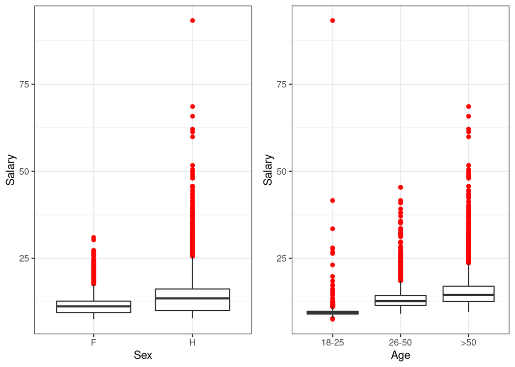

```r
 boxplot_salary_sex <- ggplot(data) +
  geom_boxplot(aes(y=salary,x=sex),outlier.colour="red")+
  xlab("Sex") +
  ylab("Salary") +
  theme_bw()

 boxplot_salary_age <- ggplot(data) +
  geom_boxplot(aes(y=salary,x=age),outlier.colour="red")+
  xlab("Age") +
  ylab("Salary") +
  theme_bw()

ggarrange(boxplot_salary_sex,
          boxplot_salary_age,
          ncol=2, nrow = 1)
```

No hay nada que indique que los importes extremos obtenidos sean sean erróneos, la entidad origen de los datos (el Instituto de Estadística de Francia) es fiable y simplemente hay personas que ganan mucho (o muy poco) dinero. También hay que tener en cuenta que estos datos extremos estarán suavizados al tratarse de medias.

Mostramos los registros con los salarios mínimo y máximo.

```r
data %>% filter (salary == max(salary) | salary==min(salary))
```

```
##   codgeo sex   age town_sme_percent town_population salary salary_factor
## 1  31375   F 18-25              100            2996    7.5        1. low
## 2  59398   H 18-25              100            2820   93.3       3. high
```

Identificamos ahora los valores extremos en el atributo población.

```r
summary(data$town_population)
```

```
##    Min. 1st Qu.  Median    Mean 3rd Qu.    Max.
##    1630    2656    3978    9465    7589 2173279
```

Comprobamos que la ciudad con la mayor población, 2.173.279, es París.

```r
codgeo_most_populated <- data %>% filter (town_population == max(town_population)) %>% select(codgeo) %>% distinct()

population_df %>% filter(CODGEO %in% codgeo_most_populated) %>% select (CODGEO,LIBGEO,NB) %>%
  group_by(CODGEO,LIBGEO) %>%
  summarise(population = sum(NB) ,.groups="drop") %>% display_table()
```

| CODGEO | LIBGEO | population |
| --- | --- | --- |
| 75056 | Paris | 2173279 |

# 5 Análisis de los datos

Mostramos el resumen de los datos

```r
summary(data)
```

```
##     codgeo          sex          age        town_sme_percent town_population
##  Length:30636       F:15318   18-25:10212   Min.   : 88.00   Min.   :   1630
##  Class :character   H:15318   26-50:10212   1st Qu.: 99.34   1st Qu.:   2656
##  Mode  :character             >50  :10212   Median :100.00   Median :   3978
##                                             Mean   : 99.54   Mean   :   9465
##                                             3rd Qu.:100.00   3rd Qu.:   7589
##                                             Max.   :100.00   Max.   :2173279
##      salary        salary_factor
##  Min.   : 7.50   1. low   : 8520
##  1st Qu.: 9.80   2. medium:13464
##  Median :12.00   3. high  : 8652
##  Mean   :12.74
##  3rd Qu.:14.50
##  Max.   :93.30
```

Mostramos la distribución de las variables cuantitativas usando histogramas de frecuencias absolutas.

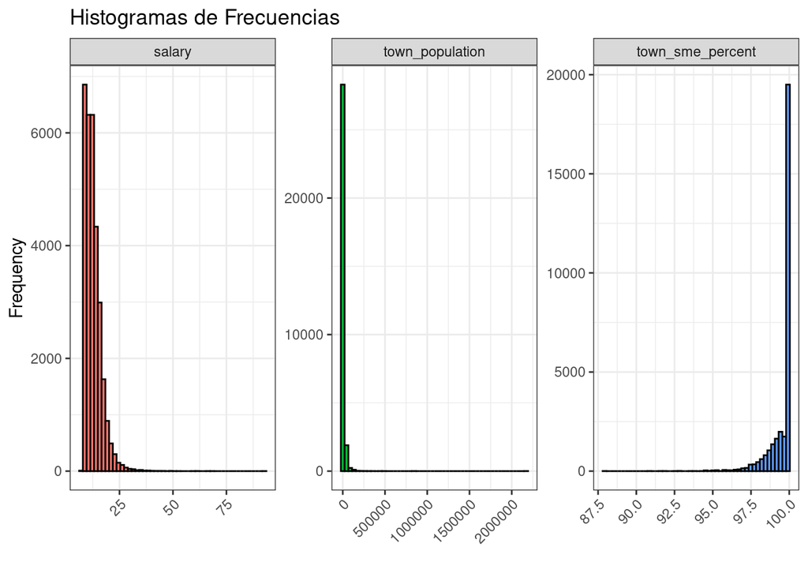

```r
# Histogramas de frecuencias
data %>% select(town_sme_percent, town_population, salary) %>%
         pivot_longer(cols = everything(),
                      names_to = "attribute",
                      values_to = "value") %>%
         ggplot(aes(x=value, fill=attribute)) +
            geom_histogram(colour="black",show.legend=FALSE,bins = 50) +
            facet_wrap(~attribute,scales="free") +
            labs(x="", y="Frequency",
            title="Histogramas de Frecuencias") +
            theme_bw() +
            theme(axis.text.x = element_text(angle = 45, hjust = 1))
```

Mostramos la distribución de las variables categóricas del conjunto de datos usando diagramas de barras de las frecuencias relativas.

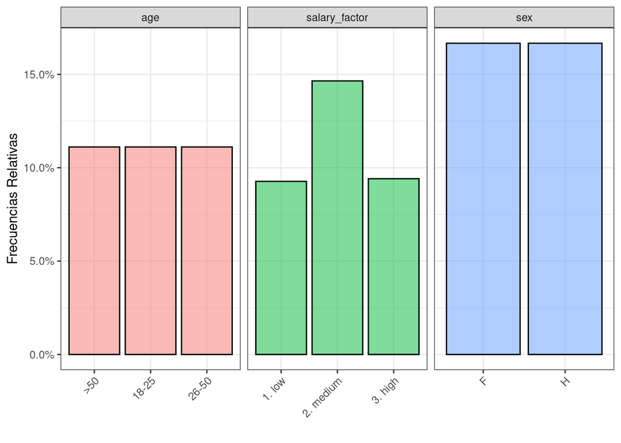

```r
data %>% select(sex, age, salary_factor) %>%
         pivot_longer(cols = everything(),
                      names_to = "attribute",
                      values_to = "value" ,
                      values_ptypes = list(value = 'character')) %>%
         group_by(attribute,value) %>%
         summarise(n = n(), .groups = "drop") %>%
         mutate(freq = n / sum(n)) %>%
         ggplot(aes(x=value, y=freq,fill=attribute)) +
            geom_bar(stat = "identity",
                     colour="black",alpha=0.5,show.legend=FALSE) +
            facet_wrap(~attribute, scales="free_x") +
            scale_y_continuous(labels = scales::percent)+
            ylab("Frecuencias Relativas")+
            xlab("")+
            theme_bw()+
            theme(axis.text.x = element_text(angle = 45, hjust = 1))
```

Debido a la forma de construir el conjunto de datos, convirtiendo los datos originales en formato de tabla ancha a una tabla larga, es normal que exista una distribución perfecta para las edades y el sexo.

Mostramos de forma gráfica la relación del sexo con el salario y la edad

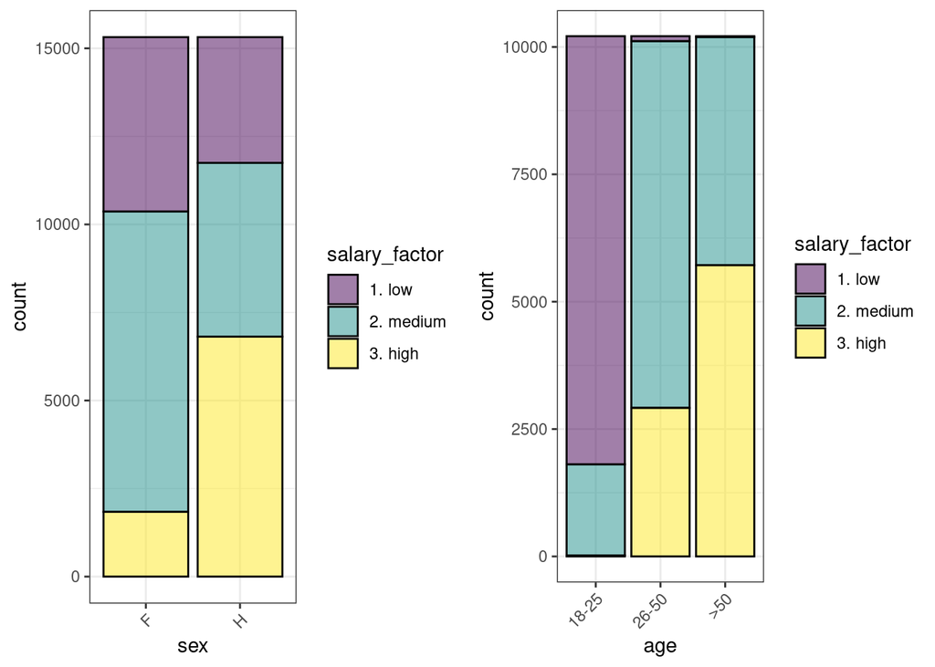

```r
# Visualizamos la relación entre las variables "sex" y "salary_factor":
bar_salary_sex <- ggplot(data=data, aes(x=sex, fill=salary_factor))+
  geom_bar(colour="black",alpha=0.5) +
  theme_bw() +
  theme(axis.text.x = element_text(angle = 45, hjust = 1))

bar_salary_age <- ggplot(data=data, aes(x=age, fill=salary_factor))+
  geom_bar(colour="black",alpha=0.5) +
  theme_bw() +
  theme(axis.text.x = element_text(angle = 45, hjust = 1))

ggarrange(bar_salary_sex,
          bar_salary_age,
          ncol=2, nrow = 1)
```

En estos gráficos se aprecia una clara brecha salarial entre hombres y mujeres y un aumento de salario con la edad.

## 5.1 Planificación de los análisis a aplicar

Vamos a realizar varios análisis sobre el conjunto de datos:

- Comprobar posibles correlaciones entre las variables numéricas: el salario, el porcentaje de pymes y la población de las ciudades.
- Cálculo del intervalo de confianza de los salarios por hora en Francia.
- Realización de un contraste de hipótesis para determinar si la media del salario de los hombres es superior al de las mujeres.
- Creación de modelo de regresión lineal que nos permita predecir es salario medio con los atributos predictores del conjunto de datos (*spoiler*, no es posible, el modelo obtenido tiene una capacidad predictora muy baja, son necesarios más atributos).
- Creación de un modelo basado en reglas que nos permita, además de predecir los salarios, entender y explicar la influencia de las variables para determinar los salarios categorizados en tres rangos, bajo, medio y alto.

## 5.2 Comprobación de la normalidad y homogeneidad de la varianza

Comprobamos si los salarios siguen una distribución normal usando un gráfico cuantil-cuantil (Q-Q plot) .

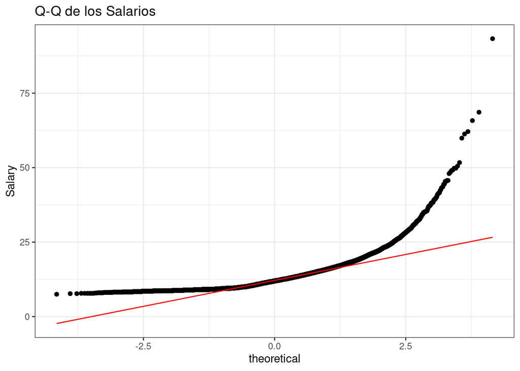

```r
ggplot(data, aes(sample = salary)) +
  stat_qq() +
  stat_qq_line(color="Red") +
  ylab("Salary") +
  labs(title="Q-Q de los Salarios") +
  theme_bw()
```

En el gráfico vemos que los salarios no siguen una distribución normal ya que no se ajustan a la linea diagonal.

Comprobamos la homogeneidad de las varianzas del salario para hombres y mujeres usando el *Test de Levene*. El test considera como hipótesis nula que la varianza es igual entre los grupos y como hipótesis alternativa que no lo es.

```r
leveneTest(y=data$salary, group = data$sex, center="median")
```

```
## Levene's Test for Homogeneity of Variance (center = "median")
##          Df F value    Pr(>F)
## group     1  2713.5 < 2.2e-16 ***
##       30634
## ---
## Signif. codes:  0 '***' 0.001 '**' 0.01 '*' 0.05 '.' 0.1 ' ' 1
```

Dado que el *p-valor* es menor que el nivel de significación, es significativo y rechazamos la hipótesis nula en favor de la hipótesis alternativa, es decir, existen diferencias significativas entre las varianzas de los grupos.

## 5.3 Pruebas estadísticas y modelos

### 5.3.1 Correlaciones

```r
matrix_cor <- cor(data[,4:6])
matrix_cor %>% display_table()
```

|  | town_sme_percent | town_population | salary |
| --- | --- | --- | --- |
| town_sme_percent | 1.0000000 | -0.0394813 | -0.0322135 |
| town_population | -0.0394813 | 1.0000000 | 0.0482082 |
| salary | -0.0322135 | 0.0482082 | 1.0000000 |

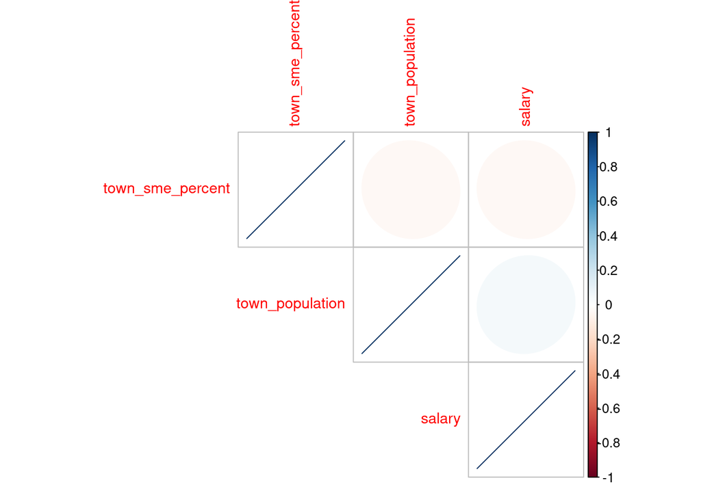

```r
corrplot(matrix_cor, type="upper", method="ellipse", tl.cex=0.9)
```

La correlación entre el salario, la población y el porcentaje de pymes en las ciudades en baja.

### 5.3.2 Intervalo de confianza

Calculamos usando la muestra de datos y la distribución *t de Student* el intervalo de confianza del 95% del salario medio.

```r
t.test(data$salary, conf.level = 0.95, alternative = "two.sided")
```

```
##
##  One Sample t-test
##
## data:  data$salary
## t = 577.79, df = 30635, p-value < 2.2e-16
## alternative hypothesis: true mean is not equal to 0
## 95 percent confidence interval:
##  12.69201 12.77842
## sample estimates:
## mean of x
##  12.73521
```

El intervalo (12.69201, 12.77842) es un intervalo de confianza con un nivel del 95% para la media de los salarios en Francia. Es decir, la media de los salarios por hora en Francia se encuentra entre 12,69 € y 12,78 €, con una confianza del 95%.

### 5.3.3 Contraste del salario entre hombres y mujeres

Realizamos el contraste entre las medias de los salarios de hombres y mujeres, para determinar si la media de los salarios de los hombres es mayor a la media de los salarios de las mujeres con un nivel de confianza del 95%.

Definimos las siguientes hipótesis nula (*H<sub>0</sub>*) y alternativa (*H<sub>1</sub>*), donde $\mu_1$ es la media del salario de los hombres y $\mu_2$ es la media del salario las mujeres.

$$H_0: \mu_1 - \mu_2 = 0 \\
H_1: \mu_1-\mu_2 > 0$$

Los salarios no siguen una distribución normal y según el *Test de Levane* las varianzas poblacionales son diferentes, por lo que aplicaremos el siguiente estadístico usado para muestras grandes (más de 30) no normales:

$$z = \frac{\overline x_1 - \overline x_2} {\sqrt { {\frac {s_{1}^{2}} {n_1}} + {\frac {s_{2}^{2}} {n_2}}}}$$

Como la hipótesis alternativa es unilateral calculamos el *p-valor* correspondiente al estadístico $z$ tal que $p = P(Z>z)$. Si el *p-valor* es mayor o igual que el nivel de significación (en nuestro caso 0,05) aceptamos la hipótesis nula, en caso contrario la rechazamos.

Calculamos el tamaño, media y la desviación estándar de las muestras de los salarios de mujeres y hombre.

```r
nivel_confianza <- 0.95
nivel_significacion <- 1-nivel_confianza

salary1 <- data %>% filter(sex=="H") %>% select (salary)
salary2 <- data %>% filter(sex=="F") %>% select (salary)

n1=length(salary1$salary)
xm1 <- mean(salary1$salary)
s1 <- sd(salary1$salary)

n2=length(salary2$salary)
xm2 <- mean(salary2$salary)
s2 <- sd(salary2$salary)

cat("Nivel de confianza: ",nivel_confianza,"\n")
cat("Nivel de significación: ",nivel_significacion,"\n\n")

cat("Cálculos para la muestra de salarios de las hombres","\n")
cat("\t","Tamaño de la muestra: ",n1,"\n")
cat("\t","Media: ",xm1,"\n")
cat("\t","Desviación estándar muestral: ",s1,"\n")

cat("Cálculos para la muestra de salarios de los mujeres","\n")
cat("\t","Tamaño de la muestra: ",n2,"\n")
cat("\t","Media: ",xm2,"\n")
cat("\t","Desviación estándar muestral: ",s2,"\n")
```

```
## Nivel de confianza:  0.95
## Nivel de significación:  0.05
##
## Cálculos para la muestra de salarios de las hombres
##   Tamaño de la muestra:  15318
##   Media:  14.00192
##   Desviación estándar muestral:  4.562874
## Cálculos para la muestra de salarios de los mujeres
##   Tamaño de la muestra:  15318
##   Media:  11.46851
##   Desviación estándar muestral:  2.395653
```

Usando estos datos, calculamos el estadístico de contraste $z$.

```r
z <- (xm1-xm2)/sqrt(s1^2/n1 + s2^2/n2)
z
```

```
## [1] 60.84168
```

$$z = \frac{\overline x_1 - \overline x_2} {\sqrt { {\frac {s_{1}^{2}} {n_1}} + {\frac {s_{2}^{2}} {n_2}}}}= \frac{14.0019193 - 11.4685076} {\sqrt { {\frac {4.5628735^{2}} {15318}} + {\frac {2.3956527^{2}} {15318}}}} = 60.8416822$$

Calculamos el valor del *p-valor* correspondiente al estadístico $z$.

```r
# Usamos al función pnorm para calcular el p-valor tal que p = P(Z > z)
p <- pnorm(z,lower.tail = FALSE)
p
```

```
## [1] 0
```

$$p = P(Z>z) =0$$

Dado que el *p-valor* es menor que el nivel de significación ($0 < 0.05$), es significativo y rechazamos la hipótesis nula en favor de la hipótesis alternativa, es decir, la media de los salarios de los hombres es mayor a la media de los salarios de las mujeres con un nivel de confianza del 95%.

Este mismo resultado lo podemos obtener usando la función `t.test`.

```r
t.test(salary1$salary,salary2$salary,alternative="greater", var.equal=FALSE,  conf.level=0.95)
```

```
##
##  Welch Two Sample t-test
##
## data:  salary1$salary and salary2$salary
## t = 60.842, df = 23165, p-value < 2.2e-16
## alternative hypothesis: true difference in means is greater than 0
## 95 percent confidence interval:
##  2.464918      Inf
## sample estimates:
## mean of x mean of y
##  14.00192  11.46851
```

### 5.3.4 Modelo de regresión lineal

Para la creación de los modelos particionamos de forma aleatoria el conjunto de datos en un conjunto de entrenamiento (2/3 del total) y un conjunto de datos de test que usaremos para comprobar la calidad del modelo obtenido.

```r
set.seed(1234)

in_train <- sample(nrow(data), size = nrow(data)*2/3)
train_data <- data[in_train,]
test_data <- data[-in_train,]

dim(train_data)
dim(test_data)
```

```
## [1] 20424     7
## [1] 10212     7
```

Creamos el modelo de regresión lineal múltiple para los salarios (variable `salary`) usando como predictores el resto de variables menos `salary_factor`.

```r
regression_mod <- lm(salary ~ sex + age + town_sme_percent + town_population, data = train_data)
summary(regression_mod)
```

```
##
## Call:
## lm(formula = salary ~ sex + age + town_sme_percent + town_population,
##     data = train_data)
##
## Residuals:
##    Min     1Q Median     3Q    Max
## -8.169 -1.440 -0.502  0.894 82.629
##
## Coefficients:
##                    Estimate Std. Error t value Pr(>|t|)
## (Intercept)       2.445e+01  2.148e+00  11.384  < 2e-16 ***
## sexH              2.539e+00  3.741e-02  67.888  < 2e-16 ***
## age.L             4.182e+00  3.240e-02 129.081  < 2e-16 ***
## age.Q            -6.644e-01  3.239e-02 -20.515  < 2e-16 ***
## town_sme_percent -1.310e-01  2.157e-02  -6.074 1.27e-09 ***
## town_population   4.433e-06  4.499e-07   9.854  < 2e-16 ***
## ---
## Signif. codes:  0 '***' 0.001 '**' 0.01 '*' 0.05 '.' 0.1 ' ' 1
##
## Residual standard error: 2.673 on 20418 degrees of freedom
## Multiple R-squared:  0.5158, Adjusted R-squared:  0.5157
## F-statistic:  4351 on 5 and 20418 DF,  p-value: < 2.2e-16
```

En el resumen del modelo lineal podemos ver, entre otros muchos datos, el valor del coeficiente de determinación R² ajustado (Adjusted R-squared). Cuanto más cercano a uno esté el coeficiente de determinación, mejor será la capacidad de predicción del modelo. En nuestro caso el valor es, 0.5157, es decir, el modelo de regresión lineal explica solo un 52% de la varianza de las observaciones.

A pesar de la mala calidad del modelo generado evaluamos su capacidad predictiva calculando, para el conjunto de datos de test, el RMSE (*Root Mean Squared Error*, que nos permite tener una idea de la calidad del modelo en las unidades de la variable objetivo) y el coeficiente de determinación.

```r
predicted_salary<- predict(regression_mod, test_data[, c("sex","age","town_sme_percent","town_population")])

# Formula para el RMSE sqrt(sum((predicted_salary - test_data$salary)^2)/length(test_data$salary))

test_rmse <- caret::RMSE(test_data$salary, predicted_salary)
test_r2 <- caret::R2(test_data$salary, predicted_salary)

train_rmse <- caret::RMSE(train_data$salary, regression_mod$fitted.values)
train_r2 <- caret::R2(train_data$salary, regression_mod$fitted.values)

cat("Test R-squared:", test_r2, "\n")
cat("Train R-squared:", train_r2, "\n\n")

cat("Test Root Mean Squared Error:" , test_rmse, "\n")
cat("Train Root Mean Squared Error:" , train_rmse, "\n")
```

```
## Test R-squared: 0.5184915
## Train R-squared: 0.5158494
##
## Test Root Mean Squared Error: 2.700881
## Train Root Mean Squared Error: 2.672472
```

### 5.3.5 Modelo basado en reglas

```r
predictors <- colnames(data)[!colnames(data) %in% c("codgeo","salary","salary_factor")]
rules_mod <- C5.0(x = train_data[, predictors], y=train_data$salary_factor, rules = TRUE)
rules_mod
```

```
##
## Call:
## C5.0.default(x = train_data[, predictors], y = train_data$salary_factor,
##  rules = TRUE)
##
## Rule-Based Model
## Number of samples: 20424
## Number of predictors: 4
##
## Number of Rules: 6
##
## Non-standard options: attempt to group attributes
```

```r
summary(rules_mod)
```

```
##
## Call:
## C5.0.default(x = train_data[, predictors], y = train_data$salary_factor,
##  rules = TRUE)
##
##
## C5.0 [Release 2.07 GPL Edition]      Wed Dec 23 08:24:09 2020
## -------------------------------
##
## Class specified by attribute `outcome'
##
## Read 20424 cases (5 attributes) from undefined.data
##
## Rules:
##
## Rule 1: (6836/1230, lift 2.9)
##  age = 18-25
##  ->  class 1. low  [0.820]
##
## Rule 2: (5971/1001, lift 1.9)
##  sex = F
##  age in [26-50->50]
##  town_population <= 14539
##  ->  class 2. medium  [0.832]
##
## Rule 3: (6032/1088, lift 1.9)
##  sex = F
##  age in [26-50->50]
##  town_sme_percent > 98.62386
##  ->  class 2. medium  [0.820]
##
## Rule 4: (6813/1986, lift 1.6)
##  age = 26-50
##  ->  class 2. medium  [0.708]
##
## Rule 5: (3365/418, lift 3.1)
##  sex = H
##  age = >50
##  ->  class 3. high  [0.876]
##
```

[output cut: 19 more lines]

```
##    ----  ----  ----
##    5606    81     1    (a): class 1. low
##    1217  7348   465    (b): class 2. medium
##      13  2636  3057    (c): class 3. high
##
##
##  Attribute usage:
##
##  100.00% age
##   49.28% sex
##   30.57% town_sme_percent
##   30.27% town_population
##
##
## Time: 0.0 secs
```

Usamos el conjunto de datos de test, que no hemos usado para construir el modelo, para calcular su capacidad predictiva.

```r
# Cálculo de la capacidad predictiva del modelo a partir del conjunto de test
predictSalaryFactor <- predict(rules_mod, test_data[, predictors], type="class")

predictOk <- sum(predictSalaryFactor==factor(test_data$salary_factor, ordered = FALSE))
percentPredictOk <- predictOk/length(predictSalaryFactor)*100

cat(paste0("El modelo clasifica correctamente un ", round(percentPredictOk,3),"% de las observaciones en los datos de test.","\n"))
cat(paste0("De un total de ",length(predictSalaryFactor)," observaciones, el modelo clasifica erróneamente ",length(predictSalaryFactor)-predictOk,"."))
```

```
## El modelo clasifica correctamente un 78.104% de las observaciones en los datos de test.
## De un total de 10212 observaciones, el modelo clasifica erróneamente 2236.
```

# 6 Conclusiones

- El conjunto de datos presenta datos vacíos en de solo 180 registros (de un total de 30.816) que han sido eliminados del análisis.
- No se identifican valores extremos que deban ser tratados previamente al análisis.
- Gráficamente se observan diferencias entre los salarios de hombres y mujeres, principalmente en los salarios altos.
- Los salarios bajos se concentran principalmente en la franja de edad de 18 a 25 años.
- No existe correlación entre el número de pequeñas empresas o la población de las ciudades y los salarios.
- La media de los salarios por hora en Francia se encuentra entre 12,69 € y 12,78 €, con una confianza del 95%.
- La media de los salarios de los hombres es mayor a la media de los salarios de las mujeres con un nivel de confianza del 95%.
- Con los atributos usados no es posible predecir el salario con una precisión suficiente usando un modelo de regresión lineal. Es necesario enriquecer el conjunto de datos con nuevos atributos, sería interesante por ejemplo disponer del nivel educativo o del número de horas trabajadas a la semana.
- El modelo de reglas creado clasifica correctamente un 78.1% de las observaciones en los datos de test. Dos de las reglas extraídas más significativas son que los jóvenes tienen ingresos bajos y que para tener ingresos altos hay que ser hombre y mayor de 50 años.